# Data Visualization

### Facet

| Code | Use |
| --- | --- |
| `col="<CATEGORICAL_VARIABLE>"` | Specify variable whose categories become subplots |
| `col_wrap=#` | Specify max subplots per row before subplots are wrapped onto the next row |
| `row="<CATEGORICAL_VARIABLE>"` | Specify variable who categories further divide subplots. Subplots for for a single category are arranged on single row. |

**EXAMPLES**

**Facet and Wrap**

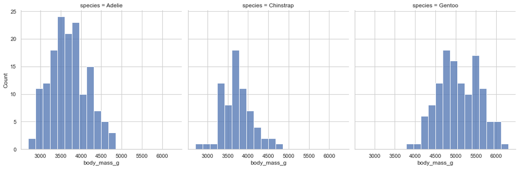

```python
sns.displot(kind="hist", data=penguins, x="body_mass_g", bins=20, col="species", col_wrap=3)
plt.show()
```

**Facet and Row**

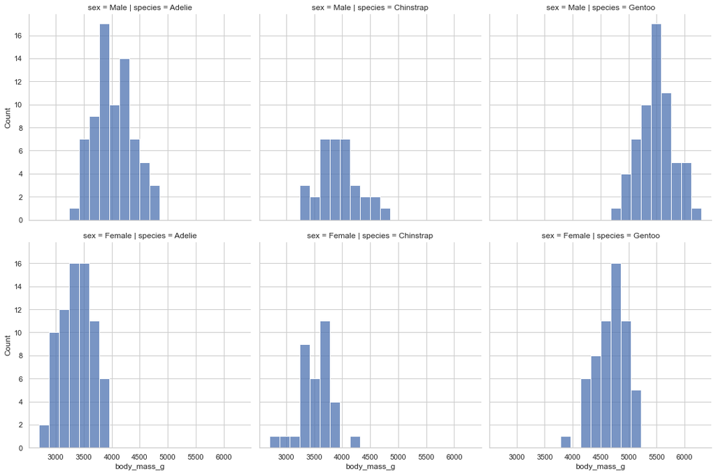

```python
sns.displot(kind="hist", data=penguins, x="body_mass_g", bins=20, col="species", row="sex")
plt.show()
```

### Title & Labels

| Code | Use |
| --- | --- |
| `.fig.suptitle(<"<TITLE>")` | FacetGrid object figure level method. Set figure title. |
| `.set_axis_labels("<X_AXIS>", "<Y_AXIS>")` | FacetGrid object figure level method Set figure axes labels. |

**EXAMPLES**

**Plot Title**

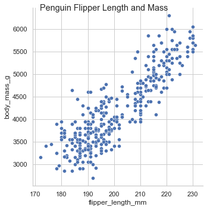

```python
g = sns.relplot(kind="scatter", data=penguins, x="flipper_length_mm", y="body_mass_g")
g.fig.suptitle("Penguin Flipper Length and Mass")
plt.show()
```

**Axes Labels**

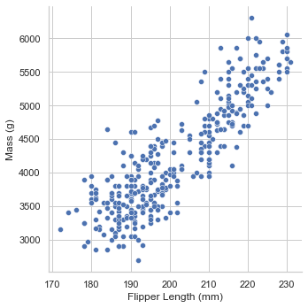

```python
g = sns.relplot(kind="scatter", data=penguins, x="flipper_length_mm", y="body_mass_g")
g.set_axis_labels("Flipper Length (mm)", "Mass (g)")
plt.show()
```

### Plot Size

| Code | Use |
| --- | --- |
| `height=#` and `aspect=#` | Figure level plotting functions have arguments for height and aspect (ratio of width to height). |

**EXAMPLES**

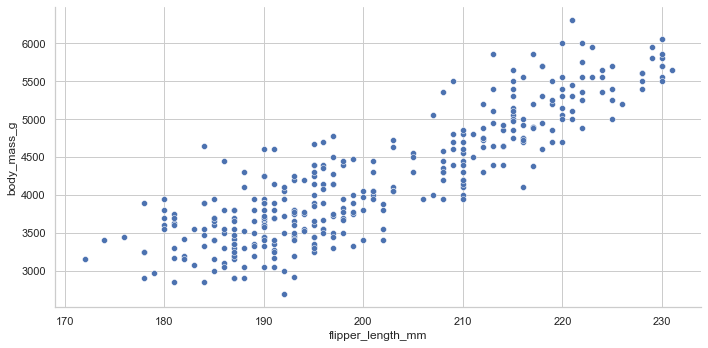

```python
fig = sns.relplot(kind="scatter", data=penguins, x="flipper_length_mm", y="body_mass_g", height=5, aspect=2)
plt.show()
```

### Aesthetics

- There are 5 plot themes:
  1. `whitegrid`--good for comparing numerical values
  2. `darkgrid`--good for comparing numerical values when dark gridlines interfere with figure
  3. `white`--good when grid not needed
  4. `dark`--good when grid not needed
  5. `ticks`--mix between white and white grid
- Themes affect many aspects of the plot at once. We can gain finer control of the plot using other functions that despine, change context, modify theme attributes, and change colors.
- The axes style is similar to the theme, but allows for a lot of customization
- The context is the spacing and size of plot elements. There are 4 context options:
  1. `paper`--small elements
  2. `notebook`--medium small elements. Default.
  3. `talk`--medium large elements
  4. `poster`--large elements
- **Spine**--the axes number lines/borders

[output not shown]

**EXAMPLES**

**Themes**

```python
sns.set_theme(style="whitegrid")
sns.relplot(kind="scatter", data=penguins, x="flipper_length_mm", y="body_mass_g")
plt.show()
```

[output not shown]

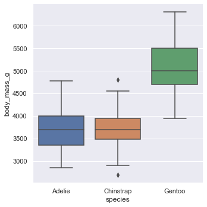

```python
sns.set_theme(style="darkgrid")
sns.catplot(kind="box", data=penguins, x="species", y="body_mass_g")
plt.show()
```

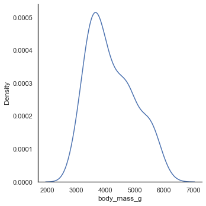

```python
sns.set_theme(style="white")
sns.displot(kind="kde", data=penguins, x="body_mass_g")
plt.show()
```

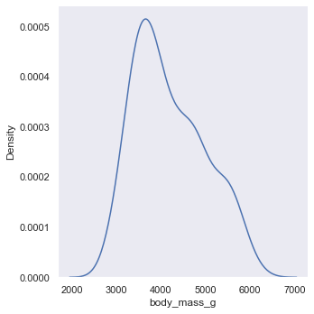

```python
sns.set_theme(style="dark")
sns.displot(kind="kde", data=penguins, x="body_mass_g")
plt.show()
```

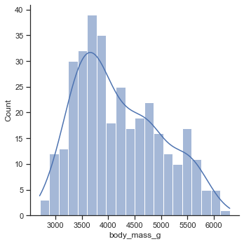

```python
sns.set_theme(style="ticks")
sns.displot(kind="hist", data=penguins, x="body_mass_g", bins=20, kde=True)
plt.show()
```

**Check Axes Style**

```python
sns.axes_style("whitegrid")
```

```
{'figure.facecolor': 'white',
 'axes.labelcolor': '.15',
 'xtick.direction': 'out',
 'ytick.direction': 'out',
 'xtick.color': '.15',
 'ytick.color': '.15',
 'axes.axisbelow': True,
 'grid.linestyle': '-',
 'text.color': '.15',
 'font.family': ['sans-serif'],
 'font.sans-serif': ['Arial',
  'DejaVu Sans',
  'Liberation Sans',
  'Bitstream Vera Sans',
  'sans-serif'],
 'lines.solid_capstyle': 'round',
 'patch.edgecolor': 'w',
 'patch.force_edgecolor': True,
 'image.cmap': 'rocket',
 'xtick.top': False,
 'ytick.right': False,
 'axes.grid': True,
 'axes.facecolor': 'white',
 'axes.edgecolor': '.8',
 'grid.color': '.8',
 'axes.spines.left': True,
 'axes.spines.bottom': True,
 'axes.spines.right': True,
 'axes.spines.top': True,
 'xtick.bottom': False,
 'ytick.left': False}
```

**Set Axes Style**

```python
sns.set_style("whitegrid")
sns.relplot(kind="scatter", data=penguins, x="flipper_length_mm", y="body_mass_g")
plt.show()
```

[output not shown]

**Check Context**

```python
sns.plotting_context("talk")
```

```
{'axes.linewidth': 1.875,
 'grid.linewidth': 1.5,
 'lines.linewidth': 2.25,
 'lines.markersize': 9.0,
 'patch.linewidth': 1.5,
 'xtick.major.width': 1.875,
 'ytick.major.width': 1.875,
 'xtick.minor.width': 1.5,
 'ytick.minor.width': 1.5,
 'xtick.major.size': 9.0,
 'ytick.major.size': 9.0,
 'xtick.minor.size': 6.0,
 'ytick.minor.size': 6.0,
 'font.size': 18.0,
 'axes.labelsize': 18.0,
 'axes.titlesize': 18.0,
 'xtick.labelsize': 16.5,
 'ytick.labelsize': 16.5,
 'legend.fontsize': 16.5,
 'legend.title_fontsize': 18.0}
```

**Set Context**

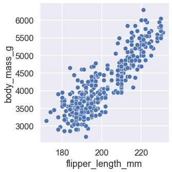

```python
sns.set_theme(style="darkgrid")
sns.set_context("talk", font_scale=1)  # Comes before plot creation
sns.relplot(kind="scatter", data=penguins, x="flipper_length_mm", y="body_mass_g")
plt.show()
```

**Despine Axes**

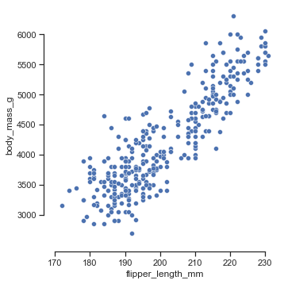

```python
sns.set_theme(style="ticks")
sns.relplot(kind="scatter", data=penguins, x="flipper_length_mm", y="body_mass_g")
sns.despine(offset=10, trim=True)  # Goes after plot creation
plt.show()
```

### Colors

[output not shown]

**EXAMPLES**

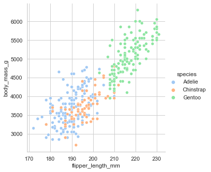

```python
sns.set_theme(style="whitegrid")
sns.relplot(
    kind="scatter",
    data=penguins,
    x="flipper_length_mm",
    y="body_mass_g",
    hue="species",
    palette="pastel"  # Prebuilt palette
)
plt.show()
```

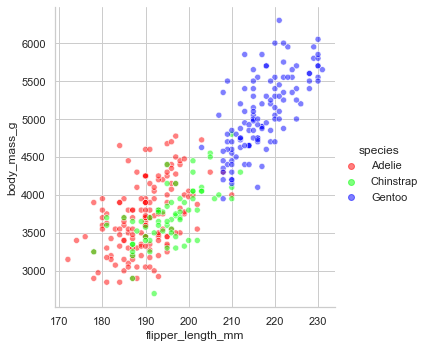

```python
sns.set_theme(style="whitegrid")
sns.relplot(
    kind="scatter",
    data=penguins,
    x="flipper_length_mm",
    y="body_mass_g",
    hue="species",
    palette=[(1, 0, 0, 0.5), (0, 1, 0, 0.5), (0, 0, 1, 0.5)]  # RGBA values with 0 to 1 range
)
plt.show()
```